# HW 9

# Problem 1

```r
x <- c(-.86, -.3, -.05, .73)
n <- rep(5, 4)
y <- c(0, 1, 3, 5)
```

## Checking the gradient.

```r
grad <- function(a, b) {
  c(sum(y/(1+exp(a+b*x)) - (n-y)/(1+exp(-a-b*x))),
    sum(x*y/(1+exp(a+b*x)) - x*(n-y)/(1+exp(-a-b*x))))
}
```

The analytic gradient evaluated at $(1, 10)$ is

```r
grad(1, 10)
```

```
[1]  0.2904300 -0.1125231
```

The finite-difference approximation of gradient at $(1, 10)$ is

```r
logp <- function(a, b) {
  sum(-y*log(1+exp(-a-b*x)) - (n-y)*log(1+exp(a+b*x)))
}

(logp(1+1e-5, 10) - logp(1, 10))/1e-5
```

```
[1] 0.2904215
```

```r
(logp(1, 10+1e-5) - logp(1, 10))/1e-5
```

```
[1] -0.1125233
```

They do match up to several decimal places.

## Implementation

```r
mean(hmc(1e4, c(0, 10))$accept)
```

```
[1] 0.6579
```

## Effective sample size.

```r
m*n
```

```
[1] 8404
```

## Check with direct approach

```r
colMeans(chain1)
```

```
[1]  1.216203 10.996225
```

Back in homework 3 the mean estimation using direct approach is $(0.9960628, 10.5482460)$. It is consistent with the direct approach. There is error because the sample size is not large enough and we don’t expect the estimation to be accurately matched.

# Problem 2

## Sampling and diagnostic

```r
y <- c(53, 57, 66, 67, 72)
joint_density <- function(N, theta, y) {
  # y can be a vector
  prod(choose(N, y)*(theta^y)*(1-theta)^(N-y))
}

banana <- function(iter, init) {
  res <- matrix(nrow=iter+1, ncol=2)
  res[1, ] <- init #c(2*max(y), 1/2) init
  for (i in 1:iter) {
    temp_N <- rpois(1, lambda=res[i, 1]) # proposal
    log_ratio <- log(joint_density(temp_N, res[i, 2], y)) -
      log(joint_density(res[i, 1], res[i, 2], y)) +
      log(dpois(temp_N, lambda=res[i, 1])) -
      log(dpois(res[i, 1], lambda=temp_N))
    temp_log_U <- log(runif(1))
    if (temp_log_U <= log_ratio) {
      res[i+1, 1] <- temp_N
    } else {
      res[i+1, 1] <- res[i, 1]
    }

    temp_theta <- runif(1, min=max(0, res[i, 2]-.2), max=min(1, res[i,2]+.2)) # proposal
    log_ratio <- log(joint_density(res[i+1, 1], temp_theta, y)) -
      log(joint_density(res[i+1, 1], res[i, 2], y))
    # proposal ratio is always one so dropped
    temp_log_U <- log(runif(1))
    if (temp_log_U <= log_ratio) {
      res[i+1, 2] <- temp_theta
    } else {
      res[i+1, 2] <- res[i, 2]
    }
  }
  return(res)
}
```

It takes too long to compute the $\hat{rho}_t$ so I will do diagnostics only monitoring the mixing.

[figure not shown]

```r
plot(chain1[, 2], type='l')
lines(chain2[, 2], col='red')
```

[figure not shown]

```r
lines(chain3[, 2], col='green')
lines(chain4[, 2], col='blue')
```

It looks like for $\theta$ the chains are indistinguishable but for $N$ there are some disturbance. I think it is good enough.

## Posterior density visualization

### 2d histogram

Let’s first take a look at a “nice” plot. It looks better comparing to the scatterplot and contour plot.

```r
library(ggplot2)
res <- burn_in(chain1) # remove burn-in
plt_data <- as.data.frame(res)
colnames(plt_data) <- c('N', 'theta')
ggplot(plt_data, aes(x=N, y=theta) ) +
  geom_bin2d(bins = 200) +
  scale_fill_continuous(type = "viridis") +
  theme_bw() + ggtitle('2d Histogram')
```

[output not shown]

### Scatterplot and contour plot

It is not reasonable to do a 200000 size scatterplot so I just randomly picked 200 points from the chain to draw the scatterplot. The coutour plot is using the entire chain.

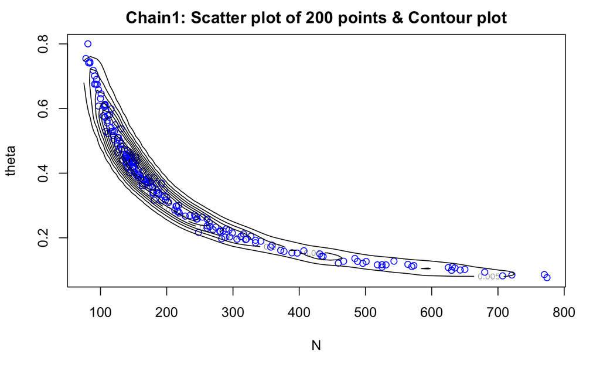

```r
library(MASS)
res <- burn_in(chain1)
ind <- sample(nrow(res), 200)
plot(res[ind, 1], res[ind, 2], col='blue',
     xlab='N', ylab='theta', main='Chain1: Scatter plot of 200 points & Contour plot')
contour(kde2d(res[, 1], res[, 2], n=100), add=TRUE)
```

```r
res <- burn_in(chain2)
ind <- sample(nrow(res), 200)
plot(res[ind, 1], res[ind, 2], col='blue',
     xlab='N', ylab='theta', main='Chain2: Scatter plot of 200 points & Contour plot')
contour(kde2d(res[, 1], res[, 2], n=100), add=TRUE)
```

[output not shown]

```r
res <- burn_in(chain3)
ind <- sample(nrow(res), 200)
plot(res[ind, 1], res[ind, 2], col='blue',
     xlab='N', ylab='theta', main='Chain3: Scatter plot of 200 points & Contour plot')
contour(kde2d(res[, 1], res[, 2], n=100), add=TRUE)
```

[output not shown]

```r
res <- burn_in(chain4)
ind <- sample(nrow(res), 200)
plot(res[ind, 1], res[ind, 2], col='blue',
     xlab='N', ylab='theta', main='Chain4: Scatter plot of 200 points & Contour plot')
contour(kde2d(res[, 1], res[, 2], n=100), add=TRUE)
```

[output not shown]

## Posterior prob. estimation for event N > 100.

```r
mean(res[, 1] > 100)
```

```
[1] 0.9409132
```